# An Example of the Coffee/Tea Market for Module 3

Hyunseung Kang

Nov. 2, 2020

Today, we’ll go over how I would have analyzed the Yelp data set, focusing specifically on obtaining **analytic insights** from the coffee/tea businesses on Yelp.

**A couple of disclosures**:

1. There is no “right” way to do this analysis. But, there are definitely “wrong” ways to analyze this data.
2. I am not an expert in natural language processing (NLP) and some of you may have a better understanding of NLP than I do.

# My General Workflow

1. Define an achievable AND useful goal for this project.
2. Clean data
3. EDA: Examine raw data and visualize data
4. Modeling: Assess statistical significance using de-biased Lasso modeling
5. Diagnostics

# Goal

I like coffee/tea shops and I wanted to see what business owners of cofffe shops can do to improve their businesses based on the Yelp reviews.

1. What features are associated with successful coffee/tea shops (based on high ratings on Yelp)
1. Type of coffee/tea served? Pastries/food/etc.
2. Ambiance?
3. Location and hours
4. Price
5. Presence of Wifi
6. Etc.
2. What can coffee shop owners do to improve their business presence on Yelp (via future high ratings on Yelp)?

For this lecture, I’ll focus on Question 1a and 1b.

# Data Cleaning

**Original Data**: $n \approx 5.36$ million reviews, $m\approx155$ thousand businesses

**Goal**: Explore businesses that serve coffee or tea on Yelp and gather insights about the coffee/tea businesses through Yelp reviews.

We achieve this goal by

1. Filter businesses (and associated reviews) with keywords “coffee”, “tea”, or “coffeehouse” (from Yelp Fusion API)
   $$n=445,615 \text{ reviews from } m=6,462 \text{ businesses }$$
2. For each review, create a word frequency vector via tokenization (R’s tidytext): $ p = 154,049$ thousand words

| review | good | coffee | ambiance | bad |
| --- | --- | --- | --- | --- |
| 1 | 3 | 1 | 0 | 0 |
| 2 | 0 | 0 | 3 | 1 |

3. Filter (i) stopwwords (e.g. “he”,“she”, “and”, from R’s tidytext defaults), (ii) stemming words, and (iii) words with low frequency across reviews (i.e. word must appear in at least 10 reviews)

**Final Data**:

1. A review-to-word $n \times p$ matrix with $n = 445,607$ reviews, $p = 30,641$ words
2. An $n$-vector of star ratings

### Notable Limitations of Data Cleaning

Businesses/Reviews Filtering

1. Some businesses serve coffee and other items (e.g. Chinese Hot Pot –> “tea” and “Chinese” on Yelp API Fusion)
2. Ignoring important attributes about businesses (e.g. WiFi, price range, location, etc.)
3. Foreign languages not filtered/translated
4. Not all coffee/tea businesses represented (due to Yelp’s limited release)

Words/Tokenization

1. Words instead of phrases tokenized and inflections/negations/ordering not captured
   1. Example 1: “Coffee was not great” –> not, great vs. “not great”)
2. Stopword not perfect (e.g. default includes “good”, “not”, “always”)
3. Lemmatization not done (i.e. a better version of stemming)
4. Word frequency counted in absolute sense (vs. tf-idf)

# Analyzing Raw Data and Background Information

```r
library(tidytext); library(dplyr)
plotWordStar <- function(stars,DTM,wordList,mfrow = c(4,4)) {
  par(mfrow = mfrow)
  col_DTM = colnames(DTM)
  for(i in 1:length(wordList)) {
    index = which(col_DTM == wordList[i])
    if(length(index) == 0) {
      warning(paste(wordList[i],"not detected"))
      next
    }
    dtm_vec = as.numeric(DTM[,index])
    names(dtm_vec) = rownames(DTM)
    starsY = rep(0,5)
    for(j in 1:5) {
      # I've changed this code to scale by total number of stars. This
      # I think provides better resolution than before.
      element = dtm_vec[as.character(stars$uniqueID[which(stars$stars == j)])]
      starsY[j]  = sum(element > 0,na.rm=TRUE) / sum(stars$stars == j)
    }
    barplot(starsY,main=wordList[i],xlab="Stars",ylab="Word Freq")
  }
}
Y = review_out %>% select(uniqueID,stars);
```

### Distribution of Specific Words

We built a function that computes the mean occucrence of the word across reviews.

1. Example: the word “bad” and three total reviews
1. Appeared 3 times in 1st review
2. Appeared 5 times in 2nd review
3. Appeared 0 times in third review
2. Then the mean occurrence for word review is (1+1+0)/3 = 0.66

This is not a perfect measure of word importance across documents (see data cleaning caveats)

We first do a sanity check with words we know are associated with bad (or good) ratings

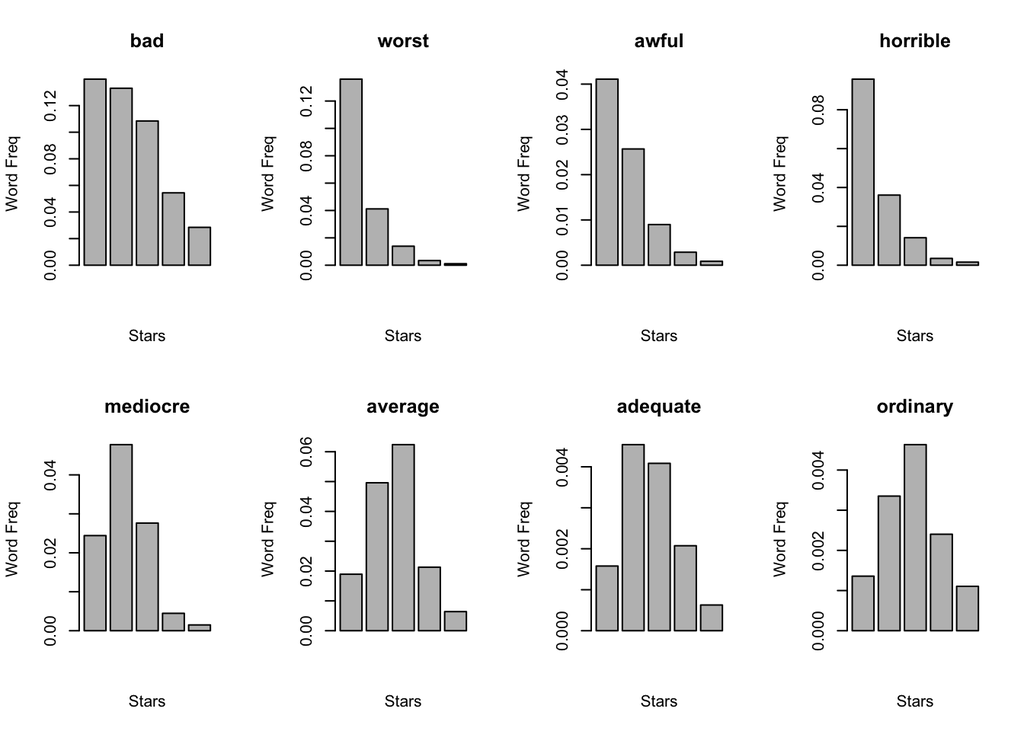

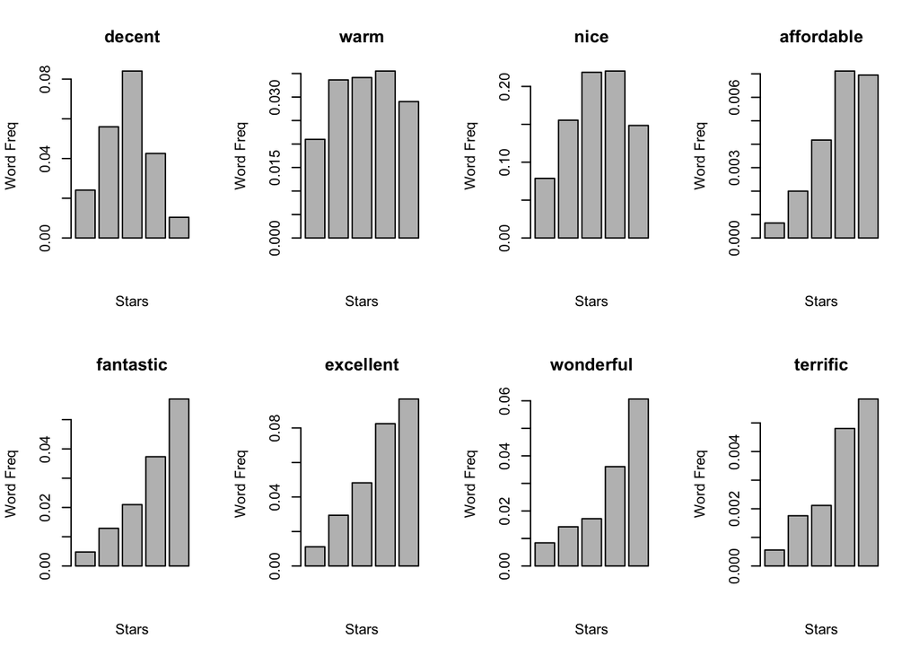

Now, we examine different types of coffee and how they are related to ratings

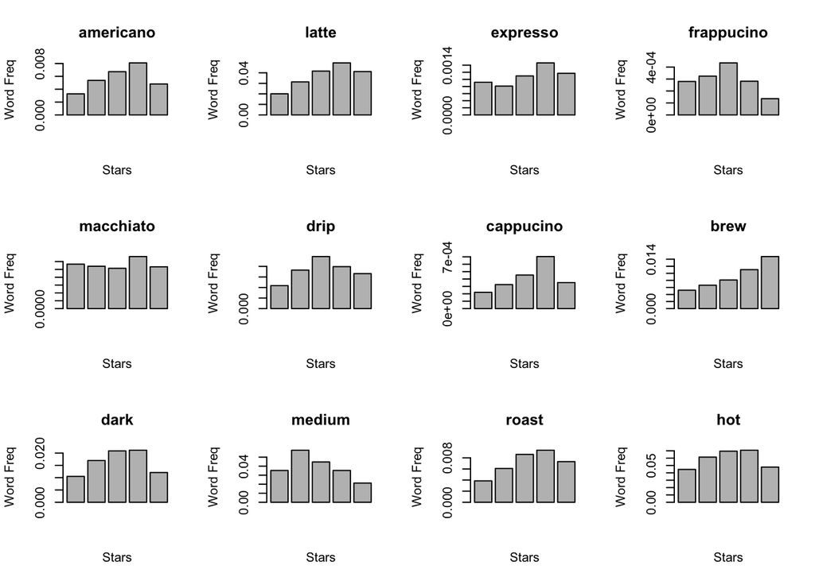

Let’s look at different types of tea.

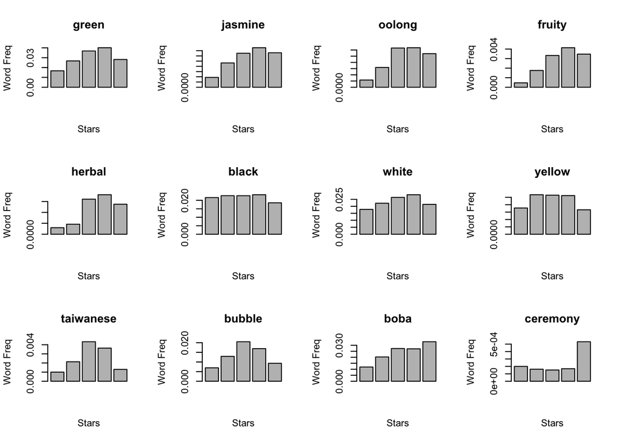

Finally, let’s look to see whether terms associated with ambiance matters.

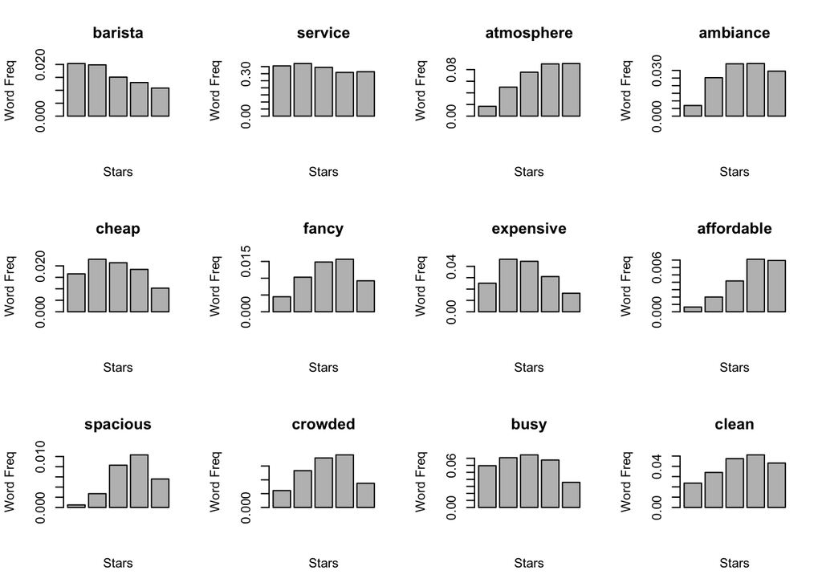

How about these terms?

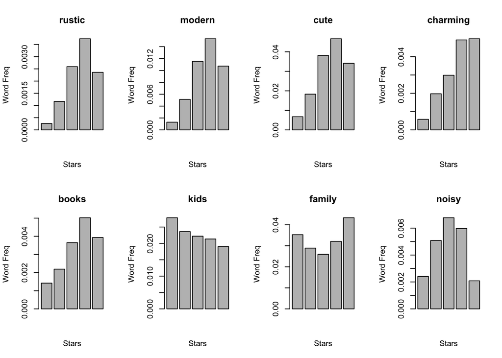

Based on this, you can start to formulate hypotheses about ideal coffee/tea environments:

1. **Type of Coffee/Tea**
   1. Coffee: dark over medium?, latte, americano
   2. Tea: tea ceremony, boba over bubbles, and every tea except black or yellow tea?
2. **Environment**: “Charming” place with no kids, family friendly environment is polarizing.

For statistical testing/modeling, you can use ANOVA or contingency tables with Bonferroni correction

1. H_0: occurrence of word BLANK in reviews is not associated with ratings
2. H_1: occurrence of word BLANK in reviews is associated with ratings
3. However, this hypothesis testing is misleading in that there could be multiple actual reasons for a word being present in a review. If I extracted business information, I could do much more better type of testing…

Also, the plots should inform you of how to better clean your data.